##### 컴퓨터공학과 3학년 202132118 박혜정

# 1. 오픈 데이터 설명

제가 준비한 오픈 데이터는 공공 데이터 포털에서 찾은 '한국토지주택공사_임대주택공급현황_전세임대' 입니다.  
이 데이터를 준비한 이유는 최근 뉴스에서 부동산 전세 사기가 많아 많은 사람들이 피해를 보고 있다는 기사를 봤습니다.  
그래서 자연스레 부동산에 관심이 생겼고, 전세와 관련된 데이터를 찾아 보다가 이 자료를 선택하게 되었습니다.  
이 데이터는 한국토지주택공사(LH)와 서울토지주택공사(SH), 경기주택토지공사(GH) 등 각 지역의 토지주택공사가 전세 임대로 제공하는 공급 현황에 대한 데이터입니다.

## 데이터 변수 설명

| 변수 | 설명 | 변수 설명 | 구분 |
| --- | --- | --- | --- |
| 지역본부 | 각 도별, 광역시별로 나눈 변수 | 서울지역본부, 부산울산지역본부, 인천지역본부, 경기남부지역본부, 강원지사, 충북지사, 대전충남지역본부, 전북지사 광주전남지역본부, 대구경북지역본부, 경남지역본부, 제주지사, 경기북부지역본부 | 범주 |
| 지자체 | 각 시와 구 별로 나눈 변수 | 종류가 많아 생략 | 범주 |
| 유형 | 전세주택의 자격별 유형에 따라 나눈 변수 | 기존주택, 다자녀가구, 소년소녀가정, 신혼부부1, 신혼부부2, 청년(19~39세), 청년(대학생), 청년(취업준비생), 청년(기숙사형) | 범주 |
| 주택유형 | 전세주택의 주택 형태에 따라 나눈 변수 | 다가구용단독주택, 단독주택, 도시형생활주택, 아파트, 연립주택, 오피스텔, 점포주택등복합용도주택, 기타, 다중주택, 기숙사및특수사회시설, 비거주용건물내주택 | 범주 |
| 방갯수 | 전세주택의 방 갯수를 나타낸 변수 |  | 연속 |
| 계약면적 | 주택 거래 계약 시 사용하는 면적으로, 전용면적과 주거 공용면적 등을 모두 합한 면적 |  | 연속 |
| 전용면적 | 공동주택에서 독점적으로 쓸 수 있는 집안 공간(발코니 제외) |  | 연속 |
| 세대원 수 | 주택에 계약 상으로 거주할 수 있는 인원 수 |  | 연속 |
| 계약일자 | 전세주택을 계약하는 날짜 | (범주형 변수로 되어 있어 날짜형 변수로 대체 예정) | 범주 |
| 전세금 | 전세주택의 계약 금액 |  | 연속 |
| 전세지원금 | 토지주택공사에서 지원하는 전세지원금 |  | 연속 |
| 월임대료 | 전세금에 대한 이자와 각종 관리비, 공과금을 합한 금액 |  | 연속 |

# 2. 데이터 보기

```python
# 판다스 라이브러리 불러오기
import pandas as pd
# 파일경로를 찾고 변수 path에 저장
path = 'C:/data/property.csv'

#read_csv() 함수로 데이터프레임 변환
df = pd.read_csv(path, encoding = 'ANSI')

# to_csv() 함수를 사용하여 csv 파일로 내보내기
df.to_csv('C:/data/property_sample.csv')

# 저장 파일 확인
path = 'C:/data/property_sample.csv'
df1 = pd.read_csv(path, engine = 'python')
df1
```

|  | Unnamed: 0 | 지역본부 | 지자체 | 유형 | 주택유형 | 방갯수 | 계약면적 | 전용면적 | 세대원수 | 계약일자 | 전세금 | 전세지원금 | 월임대료 |
| --- | --- | --- | --- | --- | --- | --- | --- | --- | --- | --- | --- | --- | --- |
| 0 | 0 | 서울지역본부 | 전세(서울강남구) | 기존주택 | 다가구용단독주택 | 1.0 | 27.7100 | 27.7100 | 0.0 | 2022-04-11 | 120000000.0 | 117000000.0 | 195000.0 |
| 1 | 1 | 서울지역본부 | 전세(서울강남구) | 기존주택 | 다가구용단독주택 | 1.0 | 20.5900 | 20.5900 | 0.0 | 2022-06-01 | 100000000.0 | 99500000.0 | 165830.0 |
| 2 | 2 | 서울지역본부 | 전세(서울강남구) | 기존주택 | 다가구용단독주택 | 1.0 | 19.4600 | 19.4600 | 1.0 | 2023-03-23 | 120000000.0 | 118900000.0 | 198160.0 |
| 3 | 3 | 서울지역본부 | 전세(서울강남구) | 기존주택 | 다가구용단독주택 | 1.0 | 18.6700 | 18.6700 | 0.0 | 2022-12-30 | 85000000.0 | 84500000.0 | 140830.0 |
| 4 | 4 | 서울지역본부 | 전세(서울강남구) | 기존주택 | 다가구용단독주택 | 1.0 | 21.6600 | 21.6600 | 0.0 | 2022-12-13 | 120000000.0 | 119050000.0 | 178570.0 |
| ... | ... | ... | ... | ... | ... | ... | ... | ... | ... | ... | ... | ... | ... |
| 304722 | 304722 | 경기북부지역본부 | 전세(경기포천시) | 청년(19~39세) | 도시형생활주택 | 3.0 | 59.7400 | 59.7400 | 0.0 | 2023-02-14 | 116000000.0 | 115000000.0 | 143750.0 |
| 304723 | 304723 | 경기북부지역본부 | 전세(경기포천시) | 청년(19~39세) | 아파트 | 3.0 | 59.3700 | 59.3700 | 2.0 | 2021-11-10 | 120000000.0 | 114000000.0 | 190000.0 |
| 304724 | 304724 | 경기북부지역본부 | 전세(경기포천시) | 청년(19~39세) | 아파트 | 3.0 | 59.3700 | 59.3700 | 1.0 | 2021-04-02 | 95000000.0 | 90250000.0 | 112810.0 |
| 304725 | 304725 | 경기북부지역본부 | 전세(경기포천시) | 청년(대학생) | 다가구용단독주택 | 1.0 | 29.4835 | 29.4835 | 1.0 | 2022-02-07 | 52500000.0 | 51500000.0 | 42910.0 |
| 304726 | 304726 | 경기북부지역본부 | 전세(경기포천시) | 청년(대학생) | 다세대주택 | 2.0 | 32.1000 | 32.1000 | 0.0 | 2022-07-21 | 41000000.0 | 40000000.0 | 16660.0 |

304727 rows × 13 columns

## 1) df1의 기본 정보 확인

```python
df1.info()
```

```
<class 'pandas.core.frame.DataFrame'>
RangeIndex: 304727 entries, 0 to 304726
Data columns (total 13 columns):
 #   Column      Non-Null Count   Dtype
---  ------      --------------   -----
 0   Unnamed: 0  304727 non-null  int64
 1   지역본부        304727 non-null  object
 2   지자체         304727 non-null  object
 3   유형          304727 non-null  object
 4   주택유형        304722 non-null  object
 5   방갯수         302742 non-null  float64
 6   계약면적        304641 non-null  float64
 7   전용면적        304641 non-null  float64
 8   세대원수        304629 non-null  float64
 9   계약일자        301319 non-null  object
 10  전세금         304718 non-null  float64
 11  전세지원금       304712 non-null  float64
 12  월임대료        304190 non-null  float64
dtypes: float64(7), int64(1), object(5)
memory usage: 30.2+ MB
```

```python
# 계약일자의 자료형이 object로 되어 있기에,이를 새로운 변수 new_계약일자를 만들어 datetime으로 변환
df1['new_계약일자'] = pd.to_datetime(df1['계약일자'])
df1.info()
```

```
<class 'pandas.core.frame.DataFrame'>
RangeIndex: 304727 entries, 0 to 304726
Data columns (total 14 columns):
 #   Column      Non-Null Count   Dtype
---  ------      --------------   -----
 0   Unnamed: 0  304727 non-null  int64
 1   지역본부        304727 non-null  object
 2   지자체         304727 non-null  object
 3   유형          304727 non-null  object
 4   주택유형        304722 non-null  object
 5   방갯수         302742 non-null  float64
 6   계약면적        304641 non-null  float64
 7   전용면적        304641 non-null  float64
 8   세대원수        304629 non-null  float64
 9   계약일자        301319 non-null  object
 10  전세금         304718 non-null  float64
 11  전세지원금       304712 non-null  float64
 12  월임대료        304190 non-null  float64
 13  new_계약일자    301319 non-null  datetime64[ns]
dtypes: datetime64[ns](1), float64(7), int64(1), object(5)
memory usage: 32.5+ MB
```

```python
# 혼란 방지를 위해 원래의 계약일자 열은 삭제
df1.drop(['계약일자'], axis = 'columns', inplace = True)
df1.info()
```

```
<class 'pandas.core.frame.DataFrame'>
RangeIndex: 304727 entries, 0 to 304726
Data columns (total 13 columns):
 #   Column      Non-Null Count   Dtype
---  ------      --------------   -----
 0   Unnamed: 0  304727 non-null  int64
 1   지역본부        304727 non-null  object
 2   지자체         304727 non-null  object
 3   유형          304727 non-null  object
 4   주택유형        304722 non-null  object
 5   방갯수         302742 non-null  float64
 6   계약면적        304641 non-null  float64
 7   전용면적        304641 non-null  float64
 8   세대원수        304629 non-null  float64
 9   전세금         304718 non-null  float64
 10  전세지원금       304712 non-null  float64
 11  월임대료        304190 non-null  float64
 12  new_계약일자    301319 non-null  datetime64[ns]
dtypes: datetime64[ns](1), float64(7), int64(1), object(4)
memory usage: 30.2+ MB
```

```python
# 열을 삭제한 데이터프레임 재확인
df1
```

|  | Unnamed: 0 | 지역본부 | 지자체 | 유형 | 주택유형 | 방갯수 | 계약면적 | 전용면적 | 세대원수 | 전세금 | 전세지원금 | 월임대료 | new_계약일자 |
| --- | --- | --- | --- | --- | --- | --- | --- | --- | --- | --- | --- | --- | --- |
| 0 | 0 | 서울지역본부 | 전세(서울강남구) | 기존주택 | 다가구용단독주택 | 1.0 | 27.7100 | 27.7100 | 0.0 | 120000000.0 | 117000000.0 | 195000.0 | 2022-04-11 |
| 1 | 1 | 서울지역본부 | 전세(서울강남구) | 기존주택 | 다가구용단독주택 | 1.0 | 20.5900 | 20.5900 | 0.0 | 100000000.0 | 99500000.0 | 165830.0 | 2022-06-01 |
| 2 | 2 | 서울지역본부 | 전세(서울강남구) | 기존주택 | 다가구용단독주택 | 1.0 | 19.4600 | 19.4600 | 1.0 | 120000000.0 | 118900000.0 | 198160.0 | 2023-03-23 |
| 3 | 3 | 서울지역본부 | 전세(서울강남구) | 기존주택 | 다가구용단독주택 | 1.0 | 18.6700 | 18.6700 | 0.0 | 85000000.0 | 84500000.0 | 140830.0 | 2022-12-30 |
| 4 | 4 | 서울지역본부 | 전세(서울강남구) | 기존주택 | 다가구용단독주택 | 1.0 | 21.6600 | 21.6600 | 0.0 | 120000000.0 | 119050000.0 | 178570.0 | 2022-12-13 |
| ... | ... | ... | ... | ... | ... | ... | ... | ... | ... | ... | ... | ... | ... |
| 304722 | 304722 | 경기북부지역본부 | 전세(경기포천시) | 청년(19~39세) | 도시형생활주택 | 3.0 | 59.7400 | 59.7400 | 0.0 | 116000000.0 | 115000000.0 | 143750.0 | 2023-02-14 |
| 304723 | 304723 | 경기북부지역본부 | 전세(경기포천시) | 청년(19~39세) | 아파트 | 3.0 | 59.3700 | 59.3700 | 2.0 | 120000000.0 | 114000000.0 | 190000.0 | 2021-11-10 |
| 304724 | 304724 | 경기북부지역본부 | 전세(경기포천시) | 청년(19~39세) | 아파트 | 3.0 | 59.3700 | 59.3700 | 1.0 | 95000000.0 | 90250000.0 | 112810.0 | 2021-04-02 |
| 304725 | 304725 | 경기북부지역본부 | 전세(경기포천시) | 청년(대학생) | 다가구용단독주택 | 1.0 | 29.4835 | 29.4835 | 1.0 | 52500000.0 | 51500000.0 | 42910.0 | 2022-02-07 |
| 304726 | 304726 | 경기북부지역본부 | 전세(경기포천시) | 청년(대학생) | 다세대주택 | 2.0 | 32.1000 | 32.1000 | 0.0 | 41000000.0 | 40000000.0 | 16660.0 | 2022-07-21 |

304727 rows × 13 columns

## 2) 조건을 이용하여 선택하기

### (1) 전체 데이터 중, 전세금이 100,000,000 미만인 주택

(최근 전세 매물이 많이 없어 전세금이 많이 올랐는데, 그 중, 1억 이하의 주택이 얼마나 있는지 확인하기 위해 조사했습니다.)

```python
df1[df1['전세금'] < 100000000]
```

|  | Unnamed: 0 | 지역본부 | 지자체 | 유형 | 주택유형 | 방갯수 | 계약면적 | 전용면적 | 세대원수 | 전세금 | 전세지원금 | 월임대료 | new_계약일자 |
| --- | --- | --- | --- | --- | --- | --- | --- | --- | --- | --- | --- | --- | --- |
| 3 | 3 | 서울지역본부 | 전세(서울강남구) | 기존주택 | 다가구용단독주택 | 1.0 | 18.6700 | 18.6700 | 0.0 | 85000000.0 | 84500000.0 | 140830.0 | 2022-12-30 |
| 7 | 7 | 서울지역본부 | 전세(서울강남구) | 기존주택 | 다가구용단독주택 | 1.0 | 30.6200 | 30.6200 | 0.0 | 90000000.0 | 84900000.0 | 127350.0 | 2022-07-29 |
| 8 | 8 | 서울지역본부 | 전세(서울강남구) | 기존주택 | 다가구용단독주택 | 1.0 | 45.6800 | 45.6800 | 0.0 | 90000000.0 | 84600000.0 | 126900.0 | 2022-04-24 |
| 13 | 13 | 서울지역본부 | 전세(서울강남구) | 기존주택 | 다가구용단독주택 | 1.0 | 17.3560 | 17.3560 | 0.0 | 80000000.0 | 79500000.0 | 119250.0 | 2021-05-15 |
| 16 | 16 | 서울지역본부 | 전세(서울강남구) | 기존주택 | 다가구용단독주택 | 1.0 | 26.2400 | 26.2400 | 0.0 | 99200000.0 | 98700000.0 | 164500.0 | 2022-11-02 |
| ... | ... | ... | ... | ... | ... | ... | ... | ... | ... | ... | ... | ... | ... |
| 304718 | 304718 | 경기북부지역본부 | 전세(경기포천시) | 청년(19~39세) | 다세대주택 | 3.0 | 51.0200 | 51.0200 | 2.0 | 60000000.0 | 59000000.0 | 49160.0 | 2021-08-07 |
| 304719 | 304719 | 경기북부지역본부 | 전세(경기포천시) | 청년(19~39세) | 도시형생활주택 | 2.0 | 45.6800 | 45.6800 | 0.0 | 80000000.0 | 76000000.0 | 126660.0 | 2022-07-21 |
| 304724 | 304724 | 경기북부지역본부 | 전세(경기포천시) | 청년(19~39세) | 아파트 | 3.0 | 59.3700 | 59.3700 | 1.0 | 95000000.0 | 90250000.0 | 112810.0 | 2021-04-02 |
| 304725 | 304725 | 경기북부지역본부 | 전세(경기포천시) | 청년(대학생) | 다가구용단독주택 | 1.0 | 29.4835 | 29.4835 | 1.0 | 52500000.0 | 51500000.0 | 42910.0 | 2022-02-07 |
| 304726 | 304726 | 경기북부지역본부 | 전세(경기포천시) | 청년(대학생) | 다세대주택 | 2.0 | 32.1000 | 32.1000 | 0.0 | 41000000.0 | 40000000.0 | 16660.0 | 2022-07-21 |

199883 rows × 13 columns

### (2) and 조건 - '전세금'이 1억 이하이면서 '지역본부'가 서울인 주택

(위에서도 말했듯이 전세금이 가파르게 상승하고 있는 요즘, 특히 서울은 다른 지역에 비해 확연히 전세금이 높기에 1억 이하인 서울의 전세 주택이 있는지 확인하기 위해 조사했습니다.)

```python
df1[(df1['전세금'] < 100000000) & (df1['지역본부'] == '서울지역본부')]
```

|  | Unnamed: 0 | 지역본부 | 지자체 | 유형 | 주택유형 | 방갯수 | 계약면적 | 전용면적 | 세대원수 | 전세금 | 전세지원금 | 월임대료 | new_계약일자 |
| --- | --- | --- | --- | --- | --- | --- | --- | --- | --- | --- | --- | --- | --- |
| 3 | 3 | 서울지역본부 | 전세(서울강남구) | 기존주택 | 다가구용단독주택 | 1.0 | 18.670 | 18.670 | 0.0 | 85000000.0 | 84500000.0 | 140830.0 | 2022-12-30 |
| 7 | 7 | 서울지역본부 | 전세(서울강남구) | 기존주택 | 다가구용단독주택 | 1.0 | 30.620 | 30.620 | 0.0 | 90000000.0 | 84900000.0 | 127350.0 | 2022-07-29 |
| 8 | 8 | 서울지역본부 | 전세(서울강남구) | 기존주택 | 다가구용단독주택 | 1.0 | 45.680 | 45.680 | 0.0 | 90000000.0 | 84600000.0 | 126900.0 | 2022-04-24 |
| 13 | 13 | 서울지역본부 | 전세(서울강남구) | 기존주택 | 다가구용단독주택 | 1.0 | 17.356 | 17.356 | 0.0 | 80000000.0 | 79500000.0 | 119250.0 | 2021-05-15 |
| 16 | 16 | 서울지역본부 | 전세(서울강남구) | 기존주택 | 다가구용단독주택 | 1.0 | 26.240 | 26.240 | 0.0 | 99200000.0 | 98700000.0 | 164500.0 | 2022-11-02 |
| ... | ... | ... | ... | ... | ... | ... | ... | ... | ... | ... | ... | ... | ... |
| 72758 | 72758 | 서울지역본부 | 전세(서울중랑구) | 청년(취업준비생) | 오피스텔 | 1.0 | 32.746 | 32.746 | 1.0 | 80000000.0 | 78000000.0 | 130000.0 | 2021-11-04 |
| 72760 | 72760 | 서울지역본부 | 전세(서울중랑구) | 청년(취업준비생) | 오피스텔 | 1.0 | 17.600 | 17.600 | 2.0 | 70000000.0 | 69000000.0 | 86250.0 | 2020-06-04 |
| 72766 | 72766 | 서울지역본부 | 전세(서울중랑구) | 청년(취업준비생) | 점포주택등복합용도주택 | 1.0 | 14.432 | 14.432 | 1.0 | 60000000.0 | 59000000.0 | 49160.0 | 2021-01-01 |
| 72776 | 72776 | 서울지역본부 | 전세(서울중랑구) | 청년(취업준비생) | 점포주택등복합용도주택 | 2.0 | 30.500 | 30.500 | 2.0 | 75000000.0 | 73925000.0 | 123200.0 | 2019-09-25 |
| 72778 | 72778 | 서울지역본부 | 전세(서울중랑구) | 청년(취업준비생) | 점포주택등복합용도주택 | 2.0 | 44.420 | 44.420 | 3.0 | 90000000.0 | 89000000.0 | 111250.0 | 2021-05-06 |

32313 rows × 13 columns

## 3) 파생 변수 만들기

### (1) 전세금에서 전세지원금을 뺀 '최소필요자금' 파생 변수 만들기

LH 전세 주택에 대해 알아보니 지원금의 금액에 따라 월 임대료의 금액이 달라진다고 합니다.  
그래서 입주자에게 있는 현재 재산이 많을수록 지원금을 덜 받게 되니 월 임대료가 낮아질 수 있으므로 이 변수를 추가하였습니다.

```python
df1['최소필요자금'] = df1['전세금'] - df1['전세지원금']
```

### (2) 월임대료에서 연 2%의 금리를 계산한 '이자' 파생 변수 만들기

LH에서 나온 자료에 따르면 LH 전세주택의 경우, 연 1 ~ 2%의 금리로 전세를 거주할 수 있다고 하였습니다.  
하지만, 이 데이터에는 이자에 대한 항목은 없어 연 2%의 금리로 '이자'를 새로 추가하였습니다.

```python
df1['이자'] = df1['월임대료'] * 0.02
```

### (3) 파생변수를 추가한 데이터프레임 확인

```python
df1
```

|  | Unnamed: 0 | 지역본부 | 지자체 | 유형 | 주택유형 | 방갯수 | 계약면적 | 전용면적 | 세대원수 | 전세금 | 전세지원금 | 월임대료 | new_계약일자 | 최소필요자금 | 이자 |
| --- | --- | --- | --- | --- | --- | --- | --- | --- | --- | --- | --- | --- | --- | --- | --- |
| 0 | 0 | 서울지역본부 | 전세(서울강남구) | 기존주택 | 다가구용단독주택 | 1.0 | 27.7100 | 27.7100 | 0.0 | 120000000.0 | 117000000.0 | 195000.0 | 2022-04-11 | 3000000.0 | 3900.0 |
| 1 | 1 | 서울지역본부 | 전세(서울강남구) | 기존주택 | 다가구용단독주택 | 1.0 | 20.5900 | 20.5900 | 0.0 | 100000000.0 | 99500000.0 | 165830.0 | 2022-06-01 | 500000.0 | 3316.6 |
| 2 | 2 | 서울지역본부 | 전세(서울강남구) | 기존주택 | 다가구용단독주택 | 1.0 | 19.4600 | 19.4600 | 1.0 | 120000000.0 | 118900000.0 | 198160.0 | 2023-03-23 | 1100000.0 | 3963.2 |
| 3 | 3 | 서울지역본부 | 전세(서울강남구) | 기존주택 | 다가구용단독주택 | 1.0 | 18.6700 | 18.6700 | 0.0 | 85000000.0 | 84500000.0 | 140830.0 | 2022-12-30 | 500000.0 | 2816.6 |
| 4 | 4 | 서울지역본부 | 전세(서울강남구) | 기존주택 | 다가구용단독주택 | 1.0 | 21.6600 | 21.6600 | 0.0 | 120000000.0 | 119050000.0 | 178570.0 | 2022-12-13 | 950000.0 | 3571.4 |
| ... | ... | ... | ... | ... | ... | ... | ... | ... | ... | ... | ... | ... | ... | ... | ... |
| 304722 | 304722 | 경기북부지역본부 | 전세(경기포천시) | 청년(19~39세) | 도시형생활주택 | 3.0 | 59.7400 | 59.7400 | 0.0 | 116000000.0 | 115000000.0 | 143750.0 | 2023-02-14 | 1000000.0 | 2875.0 |
| 304723 | 304723 | 경기북부지역본부 | 전세(경기포천시) | 청년(19~39세) | 아파트 | 3.0 | 59.3700 | 59.3700 | 2.0 | 120000000.0 | 114000000.0 | 190000.0 | 2021-11-10 | 6000000.0 | 3800.0 |
| 304724 | 304724 | 경기북부지역본부 | 전세(경기포천시) | 청년(19~39세) | 아파트 | 3.0 | 59.3700 | 59.3700 | 1.0 | 95000000.0 | 90250000.0 | 112810.0 | 2021-04-02 | 4750000.0 | 2256.2 |
| 304725 | 304725 | 경기북부지역본부 | 전세(경기포천시) | 청년(대학생) | 다가구용단독주택 | 1.0 | 29.4835 | 29.4835 | 1.0 | 52500000.0 | 51500000.0 | 42910.0 | 2022-02-07 | 1000000.0 | 858.2 |
| 304726 | 304726 | 경기북부지역본부 | 전세(경기포천시) | 청년(대학생) | 다세대주택 | 2.0 | 32.1000 | 32.1000 | 0.0 | 41000000.0 | 40000000.0 | 16660.0 | 2022-07-21 | 1000000.0 | 333.2 |

304727 rows × 15 columns

## 4) 범주형 빈도분석 및 교차분석

### (1) '지역본부' 범주형 빈도분석

'지역본부'를 기준으로 빈도분석을 하면, 어느 지역에 전세주택이 많은지 파악하기 쉬워집니다.

```python
df1['지역본부'].value_counts()
```

```
서울지역본부      72783
경기남부지역본부    58024
인천지역본부      28375
대구경북지역본부    28191
부산울산지역본부    24974
대전충남지역본부    24381
경기북부지역본부    18723
경남지역본부      15280
광주전남지역본부    12214
전북지사        10888
충북지사         5945
강원지사         4208
제주지사          741
Name: 지역본부, dtype: int64
```

### (2) '유형' 범주형 빈도분석

'유형'을 기준으로 빈도분석을 하면, 사람마다 입주 자격이 다르기에 각자 자격에 맞는 주택 갯수를 확인할 수 있습니다.

```python
df1['유형'].value_counts()
```

```
기존주택          159650
신혼부부           55366
청년(19~39세)     52051
청년(대학생)        11991
다자녀가구           7456
소년소녀가정          7072
신혼부부Ⅱ           7007
청년(취업준비생)       4079
청년(기숙사형)          55
Name: 유형, dtype: int64
```

### (3) '지역본부', '유형' 교차분석

'지역본부'와 '유형'을 교차 분석하면, 지역별로 각 유형의 주택이 몇 개인지 파악할 수 있습니다.

```python
pd.crosstab(df1['지역본부'], df1['유형'])
```

| 유형 지역본부 | 기존주택 | 다자녀가구 | 소년소녀가정 | 신혼부부 | 신혼부부Ⅱ | 청년(19~39세) | 청년(기숙사형) | 청년(대학생) | 청년(취업준비생) |
| --- | --- | --- | --- | --- | --- | --- | --- | --- | --- |
| 강원지사 | 1969 | 186 | 105 | 955 | 109 | 725 | 0 | 144 | 15 |
| 경기남부지역본부 | 31547 | 1146 | 1209 | 11828 | 1917 | 8409 | 11 | 1478 | 479 |
| 경기북부지역본부 | 10317 | 644 | 402 | 4515 | 702 | 1843 | 0 | 211 | 89 |
| 경남지역본부 | 8429 | 668 | 296 | 3749 | 280 | 1541 | 0 | 278 | 39 |
| 광주전남지역본부 | 5227 | 437 | 396 | 2489 | 249 | 2853 | 0 | 459 | 104 |
| 대구경북지역본부 | 14799 | 720 | 729 | 5667 | 327 | 4550 | 0 | 1226 | 173 |
| 대전충남지역본부 | 11174 | 698 | 713 | 4808 | 558 | 4706 | 0 | 1475 | 249 |
| 부산울산지역본부 | 14856 | 687 | 764 | 4068 | 335 | 3452 | 0 | 689 | 123 |
| 서울지역본부 | 37474 | 797 | 1393 | 6453 | 1522 | 17502 | 43 | 5039 | 2560 |
| 인천지역본부 | 15658 | 765 | 609 | 6862 | 636 | 3276 | 1 | 433 | 135 |
| 전북지사 | 5384 | 411 | 262 | 2233 | 198 | 1957 | 0 | 373 | 70 |
| 제주지사 | 237 | 63 | 14 | 210 | 47 | 153 | 0 | 11 | 6 |
| 충북지사 | 2579 | 234 | 180 | 1529 | 127 | 1084 | 0 | 175 | 37 |

# 3. 데이터 클린징

## 1) 결측 데이터 처리

### (1) 결측 데이터 확인

```python
df1.isnull()
```

|  | Unnamed: 0 | 지역본부 | 지자체 | 유형 | 주택유형 | 방갯수 | 계약면적 | 전용면적 | 세대원수 | 전세금 | 전세지원금 | 월임대료 | new_계약일자 | 최소필요자금 | 이자 |
| --- | --- | --- | --- | --- | --- | --- | --- | --- | --- | --- | --- | --- | --- | --- | --- |
| 0 | False | False | False | False | False | False | False | False | False | False | False | False | False | False | False |
| 1 | False | False | False | False | False | False | False | False | False | False | False | False | False | False | False |
| 2 | False | False | False | False | False | False | False | False | False | False | False | False | False | False | False |
| 3 | False | False | False | False | False | False | False | False | False | False | False | False | False | False | False |
| 4 | False | False | False | False | False | False | False | False | False | False | False | False | False | False | False |
| ... | ... | ... | ... | ... | ... | ... | ... | ... | ... | ... | ... | ... | ... | ... | ... |
| 304722 | False | False | False | False | False | False | False | False | False | False | False | False | False | False | False |
| 304723 | False | False | False | False | False | False | False | False | False | False | False | False | False | False | False |
| 304724 | False | False | False | False | False | False | False | False | False | False | False | False | False | False | False |
| 304725 | False | False | False | False | False | False | False | False | False | False | False | False | False | False | False |
| 304726 | False | False | False | False | False | False | False | False | False | False | False | False | False | False | False |

304727 rows × 15 columns

### (2) 결측 데이터 갯수 확인

```python
df1.isnull().sum()
```

```
Unnamed: 0       0
지역본부             0
지자체              0
유형               0
주택유형             5
방갯수           1985
계약면적            86
전용면적            86
세대원수            98
전세금              9
전세지원금           15
월임대료           537
new_계약일자      3408
최소필요자금          15
이자             537
dtype: int64
```

### (3) 결측 데이터 대체/제거

```python
# 결측값 제거
df2 = df1[['지역본부', '지자체', '유형', '주택유형', '방갯수', '계약면적', '전용면적', '세대원수', '전세금', '전세지원금', '월임대료', '최소필요자금', '이자', 'new_계약일자']].dropna()
```

### (4) 결측 데이터 처리 후, 재확인

```python
df2.isnull().sum()
```

```
지역본부        0
지자체         0
유형          0
주택유형        0
방갯수         0
계약면적        0
전용면적        0
세대원수        0
전세금         0
전세지원금       0
월임대료        0
최소필요자금      0
이자          0
new_계약일자    0
dtype: int64
```

## 2) 이상 데이터 처리

### (1) 이상 데이터 확인

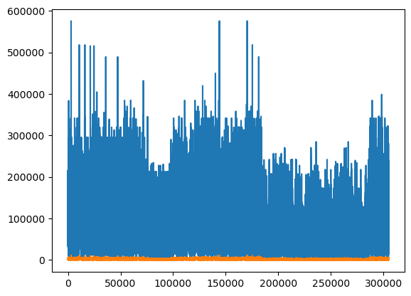

```python
# 이상 데이터를 확인하기 위해 플롯을 사용하였습니다.
# '월임대료' 이상치 시각화
import matplotlib as mpl
import matplotlib.pylab as plt
df2['월임대료'].plot(kind = 'line')
df2['이자'].plot(kind='line')
```

```python
# (맷플롯립으로 '월임대료' 시각화를 하였지만, 이상 데이터가 없어 임의로 304275와 304276 행의 월임대료와 이자를 이상치로 바꾸겠습니다.)

df2.loc[304725, '월임대료'] = 1500000.0
df2.loc[304725, '이자'] = 30000.0
df2.loc[304726, '월임대료'] = 1972000.0
df2.loc[304726, '이자'] = 39440.0

# 이상 데이터로 대체한 df2 확인
df2
```

|  | 지역본부 | 지자체 | 유형 | 주택유형 | 방갯수 | 계약면적 | 전용면적 | 세대원수 | 전세금 | 전세지원금 | 월임대료 | 최소필요자금 | 이자 | new_계약일자 |
| --- | --- | --- | --- | --- | --- | --- | --- | --- | --- | --- | --- | --- | --- | --- |
| 0 | 서울지역본부 | 전세(서울강남구) | 기존주택 | 다가구용단독주택 | 1.0 | 27.7100 | 27.7100 | 0.0 | 120000000.0 | 117000000.0 | 195000.0 | 3000000.0 | 3900.0 | 2022-04-11 |
| 1 | 서울지역본부 | 전세(서울강남구) | 기존주택 | 다가구용단독주택 | 1.0 | 20.5900 | 20.5900 | 0.0 | 100000000.0 | 99500000.0 | 165830.0 | 500000.0 | 3316.6 | 2022-06-01 |
| 2 | 서울지역본부 | 전세(서울강남구) | 기존주택 | 다가구용단독주택 | 1.0 | 19.4600 | 19.4600 | 1.0 | 120000000.0 | 118900000.0 | 198160.0 | 1100000.0 | 3963.2 | 2023-03-23 |
| 3 | 서울지역본부 | 전세(서울강남구) | 기존주택 | 다가구용단독주택 | 1.0 | 18.6700 | 18.6700 | 0.0 | 85000000.0 | 84500000.0 | 140830.0 | 500000.0 | 2816.6 | 2022-12-30 |
| 4 | 서울지역본부 | 전세(서울강남구) | 기존주택 | 다가구용단독주택 | 1.0 | 21.6600 | 21.6600 | 0.0 | 120000000.0 | 119050000.0 | 178570.0 | 950000.0 | 3571.4 | 2022-12-13 |
| ... | ... | ... | ... | ... | ... | ... | ... | ... | ... | ... | ... | ... | ... | ... |
| 304722 | 경기북부지역본부 | 전세(경기포천시) | 청년(19~39세) | 도시형생활주택 | 3.0 | 59.7400 | 59.7400 | 0.0 | 116000000.0 | 115000000.0 | 143750.0 | 1000000.0 | 2875.0 | 2023-02-14 |
| 304723 | 경기북부지역본부 | 전세(경기포천시) | 청년(19~39세) | 아파트 | 3.0 | 59.3700 | 59.3700 | 2.0 | 120000000.0 | 114000000.0 | 190000.0 | 6000000.0 | 3800.0 | 2021-11-10 |
| 304724 | 경기북부지역본부 | 전세(경기포천시) | 청년(19~39세) | 아파트 | 3.0 | 59.3700 | 59.3700 | 1.0 | 95000000.0 | 90250000.0 | 112810.0 | 4750000.0 | 2256.2 | 2021-04-02 |
| 304725 | 경기북부지역본부 | 전세(경기포천시) | 청년(대학생) | 다가구용단독주택 | 1.0 | 29.4835 | 29.4835 | 1.0 | 52500000.0 | 51500000.0 | 1500000.0 | 1000000.0 | 30000.0 | 2022-02-07 |
| 304726 | 경기북부지역본부 | 전세(경기포천시) | 청년(대학생) | 다세대주택 | 2.0 | 32.1000 | 32.1000 | 0.0 | 41000000.0 | 40000000.0 | 1972000.0 | 1000000.0 | 39440.0 | 2022-07-21 |

298695 rows × 14 columns

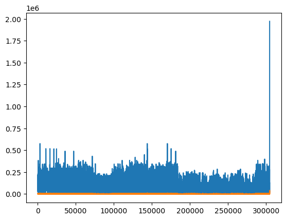

```python
# 이상 데이터로 대체한 df2의 월임대료와 이자 재 시각화
df2['월임대료'].plot(kind = 'line')
df2['이자'].plot(kind='line')
```

### (2) 이상 데이터 대체/제거

```python
# (이상값을 임의로 대체한 것이기에 다시 원래 값으로 대체하겠습니다.)
df2.loc[304725, '월임대료'] = 42910.0
df2.loc[304725, '이자'] = 858.2
df2.loc[304726, '월임대료'] = 16660.0
df2.loc[304726, '이자'] = 333.2
```

### (3) (이상 데이터를 원래의 정상 데이터로 대체한 df2) 재확인

```python
df2
```

|  | 지역본부 | 지자체 | 유형 | 주택유형 | 방갯수 | 계약면적 | 전용면적 | 세대원수 | 전세금 | 전세지원금 | 월임대료 | 최소필요자금 | 이자 | new_계약일자 |
| --- | --- | --- | --- | --- | --- | --- | --- | --- | --- | --- | --- | --- | --- | --- |
| 0 | 서울지역본부 | 전세(서울강남구) | 기존주택 | 다가구용단독주택 | 1.0 | 27.7100 | 27.7100 | 0.0 | 120000000.0 | 117000000.0 | 195000.0 | 3000000.0 | 3900.0 | 2022-04-11 |
| 1 | 서울지역본부 | 전세(서울강남구) | 기존주택 | 다가구용단독주택 | 1.0 | 20.5900 | 20.5900 | 0.0 | 100000000.0 | 99500000.0 | 165830.0 | 500000.0 | 3316.6 | 2022-06-01 |
| 2 | 서울지역본부 | 전세(서울강남구) | 기존주택 | 다가구용단독주택 | 1.0 | 19.4600 | 19.4600 | 1.0 | 120000000.0 | 118900000.0 | 198160.0 | 1100000.0 | 3963.2 | 2023-03-23 |
| 3 | 서울지역본부 | 전세(서울강남구) | 기존주택 | 다가구용단독주택 | 1.0 | 18.6700 | 18.6700 | 0.0 | 85000000.0 | 84500000.0 | 140830.0 | 500000.0 | 2816.6 | 2022-12-30 |
| 4 | 서울지역본부 | 전세(서울강남구) | 기존주택 | 다가구용단독주택 | 1.0 | 21.6600 | 21.6600 | 0.0 | 120000000.0 | 119050000.0 | 178570.0 | 950000.0 | 3571.4 | 2022-12-13 |
| ... | ... | ... | ... | ... | ... | ... | ... | ... | ... | ... | ... | ... | ... | ... |
| 304722 | 경기북부지역본부 | 전세(경기포천시) | 청년(19~39세) | 도시형생활주택 | 3.0 | 59.7400 | 59.7400 | 0.0 | 116000000.0 | 115000000.0 | 143750.0 | 1000000.0 | 2875.0 | 2023-02-14 |
| 304723 | 경기북부지역본부 | 전세(경기포천시) | 청년(19~39세) | 아파트 | 3.0 | 59.3700 | 59.3700 | 2.0 | 120000000.0 | 114000000.0 | 190000.0 | 6000000.0 | 3800.0 | 2021-11-10 |
| 304724 | 경기북부지역본부 | 전세(경기포천시) | 청년(19~39세) | 아파트 | 3.0 | 59.3700 | 59.3700 | 1.0 | 95000000.0 | 90250000.0 | 112810.0 | 4750000.0 | 2256.2 | 2021-04-02 |
| 304725 | 경기북부지역본부 | 전세(경기포천시) | 청년(대학생) | 다가구용단독주택 | 1.0 | 29.4835 | 29.4835 | 1.0 | 52500000.0 | 51500000.0 | 42910.0 | 1000000.0 | 858.2 | 2022-02-07 |
| 304726 | 경기북부지역본부 | 전세(경기포천시) | 청년(대학생) | 다세대주택 | 2.0 | 32.1000 | 32.1000 | 0.0 | 41000000.0 | 40000000.0 | 16660.0 | 1000000.0 | 333.2 | 2022-07-21 |

298695 rows × 14 columns

# 4. 데이터 탐색

## 1) 데이터 그룹 분석

##### 데이터 그룹 분석의 최종 목적

=> '지역본부'별로 그룹화하여 각 '지자체'별로 또 그룹화를 하고, 각 '유형'과 '주택유형'별로 다시 한번 그룹화를 한 뒤, 부동산 대란이었던 2021~2022년 사이가 '계약일자'였던 주택의 '전세금' 평균을 구하는 것입니다.  
=> 그리고, 위와 똑같이 그룹화하여 분석한 뒤, 2023년이 '계약일자'인 주택의 '전세금' 평균을 구하여 두 그룹을 비교할 것입니다.  
=> '지자체'는 가장 데이터가 많은 '경기수원시' 그룹으로, '유형'은 '기존주택'으로, '주택유형'은 '다세대주택'으로 하겠습니다.

### (1) 2021~2022

#### (a) '지역본부'별 그룹 분석

```python
df2_country_group = df2.groupby('지역본부')
df2_country_group
```

```
<pandas.core.groupby.generic.DataFrameGroupBy object at 0x000001D5422125E0>
```

#### (b) '지역본부' 중, '경기남부지역본부' 그룹만 확인

```python
df2_south_gyeonggi_group = df2_country_group.get_group('경기남부지역본부')
df2_south_gyeonggi_group
```

|  | 지역본부 | 지자체 | 유형 | 주택유형 | 방갯수 | 계약면적 | 전용면적 | 세대원수 | 전세금 | 전세지원금 | 월임대료 | 최소필요자금 | 이자 | new_계약일자 |
| --- | --- | --- | --- | --- | --- | --- | --- | --- | --- | --- | --- | --- | --- | --- |
| 126132 | 경기남부지역본부 | 전세(경기과천시) | 기존주택 | 다가구용단독주택 | 1.0 | 20.19 | 20.190 | 0.0 | 40000000.0 | 37610000.0 | 31340.0 | 2390000.0 | 626.8 | 2020-11-17 |
| 126133 | 경기남부지역본부 | 전세(경기과천시) | 기존주택 | 다가구용단독주택 | 1.0 | 19.73 | 19.730 | 0.0 | 50000000.0 | 46450000.0 | 58060.0 | 3550000.0 | 1161.2 | 2022-11-07 |
| 126134 | 경기남부지역본부 | 전세(경기과천시) | 기존주택 | 다가구용단독주택 | 1.0 | 19.23 | 19.230 | 1.0 | 60000000.0 | 56700000.0 | 70870.0 | 3300000.0 | 1417.4 | 2023-03-10 |
| 126135 | 경기남부지역본부 | 전세(경기과천시) | 기존주택 | 다가구용단독주택 | 1.0 | 30.05 | 30.005 | 0.0 | 65000000.0 | 61750000.0 | 92620.0 | 3250000.0 | 1852.4 | 2022-12-10 |
| 126136 | 경기남부지역본부 | 전세(경기과천시) | 기존주택 | 다가구용단독주택 | 1.0 | 53.31 | 53.310 | 0.0 | 90000000.0 | 76500000.0 | 114750.0 | 13500000.0 | 2295.0 | 2022-07-23 |
| ... | ... | ... | ... | ... | ... | ... | ... | ... | ... | ... | ... | ... | ... | ... |
| 184151 | 경기남부지역본부 | 전세(경기화성시) | 청년(취업준비생) | 점포주택등복합용도주택 | 2.0 | 55.87 | 55.870 | 2.0 | 120000000.0 | 119000000.0 | 148750.0 | 1000000.0 | 2975.0 | 2022-02-25 |
| 184152 | 경기남부지역본부 | 전세(경기화성시) | 청년(취업준비생) | 점포주택등복합용도주택 | 2.0 | 57.51 | 57.510 | 1.0 | 126000000.0 | 119000000.0 | 148750.0 | 7000000.0 | 2975.0 | 2021-10-15 |
| 184153 | 경기남부지역본부 | 전세(경기화성시) | 청년(취업준비생) | 점포주택등복합용도주택 | 2.0 | 53.25 | 53.250 | 0.0 | 110000000.0 | 109000000.0 | 136250.0 | 1000000.0 | 2725.0 | 2021-11-29 |
| 184154 | 경기남부지역본부 | 전세(경기화성시) | 청년(취업준비생) | 점포주택등복합용도주택 | 2.0 | 52.67 | 52.670 | 2.0 | 90000000.0 | 88000000.0 | 110000.0 | 2000000.0 | 2200.0 | 2021-04-05 |
| 184155 | 경기남부지역본부 | 전세(경기화성시) | 청년(취업준비생) | 점포주택등복합용도주택 | 2.0 | 56.32 | 56.320 | 2.0 | 120000000.0 | 119000000.0 | 148750.0 | 1000000.0 | 2975.0 | 2021-12-06 |

57437 rows × 14 columns

#### (c) '경기남부지역본부' 그룹 중, '지자체'별 그룹 분석

```python
df2_south_gyeonggi_local = df2_south_gyeonggi_group.groupby('지자체')
df2_south_gyeonggi_local
```

```
<pandas.core.groupby.generic.DataFrameGroupBy object at 0x000001D555491A90>
```

#### (d) (c)에서 '경기수원시' 그룹만 확인

```python
df2_suwon = df2_south_gyeonggi_local.get_group('전세(경기수원시)')
df2_suwon
```

|  | 지역본부 | 지자체 | 유형 | 주택유형 | 방갯수 | 계약면적 | 전용면적 | 세대원수 | 전세금 | 전세지원금 | 월임대료 | 최소필요자금 | 이자 | new_계약일자 |
| --- | --- | --- | --- | --- | --- | --- | --- | --- | --- | --- | --- | --- | --- | --- |
| 145144 | 경기남부지역본부 | 전세(경기수원시) | 기존주택 | 다가구용단독주택 | 1.0 | 23.14 | 23.14 | 0.0 | 40000000.0 | 39500000.0 | 32910.0 | 500000.0 | 658.2 | 2022-08-19 |
| 145145 | 경기남부지역본부 | 전세(경기수원시) | 기존주택 | 다가구용단독주택 | 1.0 | 20.83 | 20.83 | 0.0 | 35000000.0 | 34300000.0 | 28580.0 | 700000.0 | 571.6 | 2023-01-21 |
| 145146 | 경기남부지역본부 | 전세(경기수원시) | 기존주택 | 다가구용단독주택 | 1.0 | 23.44 | 23.44 | 0.0 | 90000000.0 | 89000000.0 | 133500.0 | 1000000.0 | 2670.0 | 2022-01-25 |
| 145147 | 경기남부지역본부 | 전세(경기수원시) | 기존주택 | 다가구용단독주택 | 1.0 | 32.45 | 32.45 | 0.0 | 40000000.0 | 38000000.0 | 31660.0 | 2000000.0 | 633.2 | 2021-04-01 |
| 145148 | 경기남부지역본부 | 전세(경기수원시) | 기존주택 | 다가구용단독주택 | 1.0 | 23.34 | 23.34 | 1.0 | 31000000.0 | 29450000.0 | 24540.0 | 1550000.0 | 490.8 | 2021-11-27 |
| ... | ... | ... | ... | ... | ... | ... | ... | ... | ... | ... | ... | ... | ... | ... |
| 154869 | 경기남부지역본부 | 전세(경기수원시) | 청년(취업준비생) | 점포주택등복합용도주택 | 2.0 | 47.60 | 47.60 | 1.0 | 40000000.0 | 36000000.0 | 15000.0 | 4000000.0 | 300.0 | 2022-05-11 |
| 154870 | 경기남부지역본부 | 전세(경기수원시) | 청년(취업준비생) | 점포주택등복합용도주택 | 2.0 | 45.12 | 45.12 | 3.0 | 120000000.0 | 118000000.0 | 196660.0 | 2000000.0 | 3933.2 | 2021-04-21 |
| 154871 | 경기남부지역본부 | 전세(경기수원시) | 청년(취업준비생) | 점포주택등복합용도주택 | 2.0 | 52.32 | 52.32 | 1.0 | 130000000.0 | 119000000.0 | 148750.0 | 11000000.0 | 2975.0 | 2022-07-29 |
| 154872 | 경기남부지역본부 | 전세(경기수원시) | 청년(취업준비생) | 점포주택등복합용도주택 | 2.0 | 54.77 | 54.77 | 2.0 | 107000000.0 | 106000000.0 | 132500.0 | 1000000.0 | 2650.0 | 2021-11-29 |
| 154873 | 경기남부지역본부 | 전세(경기수원시) | 청년(취업준비생) | 점포주택등복합용도주택 | 2.0 | 41.63 | 41.63 | 1.0 | 100000000.0 | 99000000.0 | 123750.0 | 1000000.0 | 2475.0 | 2021-08-05 |

9607 rows × 14 columns

#### (e) '경기수원시' 그룹 중, '유형'별 그룹 분석

```python
df2_type = df2_suwon.groupby('유형')
df2_type
```

```
<pandas.core.groupby.generic.DataFrameGroupBy object at 0x000001D542204D90>
```

#### (f) (d)에서 '기존주택' 그룹만 확인

```python
df2_existing = df2_type.get_group('기존주택')
df2_existing
```

|  | 지역본부 | 지자체 | 유형 | 주택유형 | 방갯수 | 계약면적 | 전용면적 | 세대원수 | 전세금 | 전세지원금 | 월임대료 | 최소필요자금 | 이자 | new_계약일자 |
| --- | --- | --- | --- | --- | --- | --- | --- | --- | --- | --- | --- | --- | --- | --- |
| 145144 | 경기남부지역본부 | 전세(경기수원시) | 기존주택 | 다가구용단독주택 | 1.0 | 23.14 | 23.14 | 0.0 | 40000000.0 | 39500000.0 | 32910.0 | 500000.0 | 658.2 | 2022-08-19 |
| 145145 | 경기남부지역본부 | 전세(경기수원시) | 기존주택 | 다가구용단독주택 | 1.0 | 20.83 | 20.83 | 0.0 | 35000000.0 | 34300000.0 | 28580.0 | 700000.0 | 571.6 | 2023-01-21 |
| 145146 | 경기남부지역본부 | 전세(경기수원시) | 기존주택 | 다가구용단독주택 | 1.0 | 23.44 | 23.44 | 0.0 | 90000000.0 | 89000000.0 | 133500.0 | 1000000.0 | 2670.0 | 2022-01-25 |
| 145147 | 경기남부지역본부 | 전세(경기수원시) | 기존주택 | 다가구용단독주택 | 1.0 | 32.45 | 32.45 | 0.0 | 40000000.0 | 38000000.0 | 31660.0 | 2000000.0 | 633.2 | 2021-04-01 |
| 145148 | 경기남부지역본부 | 전세(경기수원시) | 기존주택 | 다가구용단독주택 | 1.0 | 23.34 | 23.34 | 1.0 | 31000000.0 | 29450000.0 | 24540.0 | 1550000.0 | 490.8 | 2021-11-27 |
| ... | ... | ... | ... | ... | ... | ... | ... | ... | ... | ... | ... | ... | ... | ... |
| 150003 | 경기남부지역본부 | 전세(경기수원시) | 기존주택 | 점포주택등복합용도주택 | 3.0 | 72.13 | 72.13 | 3.0 | 90000000.0 | 84450000.0 | 167480.0 | 5550000.0 | 3349.6 | 2022-05-02 |
| 150004 | 경기남부지역본부 | 전세(경기수원시) | 기존주택 | 점포주택등복합용도주택 | 3.0 | 73.17 | 73.17 | 2.0 | 50000000.0 | 45000000.0 | 56250.0 | 5000000.0 | 1125.0 | 2022-06-02 |
| 150005 | 경기남부지역본부 | 전세(경기수원시) | 기존주택 | 점포주택등복합용도주택 | 3.0 | 72.60 | 72.60 | 1.0 | 60000000.0 | 57000000.0 | 61750.0 | 3000000.0 | 1235.0 | 2022-07-07 |
| 150006 | 경기남부지역본부 | 전세(경기수원시) | 기존주택 | 점포주택등복합용도주택 | 3.0 | 64.50 | 64.50 | 2.0 | 130000000.0 | 104500000.0 | 282150.0 | 25500000.0 | 5643.0 | 2021-03-31 |
| 150007 | 경기남부지역본부 | 전세(경기수원시) | 기존주택 | 점포주택등복합용도주택 | 3.0 | 69.51 | 69.51 | 2.0 | 150000000.0 | 114000000.0 | 142500.0 | 36000000.0 | 2850.0 | 2022-07-11 |

4809 rows × 14 columns

#### (g) '기존주택' 그룹 중, '주택유형'별 그룹 분석

```python
df2_home_type = df2_existing.groupby('주택유형')
df2_home_type
```

```
<pandas.core.groupby.generic.DataFrameGroupBy object at 0x000001D555491C10>
```

#### (h) (g)에서 '다세대주택' 그룹만 확인

```python
df2_multi_unit_home = df2_home_type.get_group('다세대주택')
df2_multi_unit_home
```

|  | 지역본부 | 지자체 | 유형 | 주택유형 | 방갯수 | 계약면적 | 전용면적 | 세대원수 | 전세금 | 전세지원금 | 월임대료 | 최소필요자금 | 이자 | new_계약일자 |
| --- | --- | --- | --- | --- | --- | --- | --- | --- | --- | --- | --- | --- | --- | --- |
| 145763 | 경기남부지역본부 | 전세(경기수원시) | 기존주택 | 다세대주택 | 1.0 | 48.24 | 48.24 | 0.0 | 80000000.0 | 71250000.0 | 106870.0 | 8750000.0 | 2137.4 | 2020-08-17 |
| 145764 | 경기남부지역본부 | 전세(경기수원시) | 기존주택 | 다세대주택 | 1.0 | 20.70 | 20.70 | 0.0 | 65000000.0 | 61750000.0 | 92620.0 | 3250000.0 | 1852.4 | 2022-05-19 |
| 145765 | 경기남부지역본부 | 전세(경기수원시) | 기존주택 | 다세대주택 | 1.0 | 42.25 | 42.25 | 2.0 | 65000000.0 | 61750000.0 | 102910.0 | 3250000.0 | 2058.2 | 2022-07-14 |
| 145766 | 경기남부지역본부 | 전세(경기수원시) | 기존주택 | 다세대주택 | 1.0 | 20.70 | 20.70 | 0.0 | 65000000.0 | 61600000.0 | 102660.0 | 3400000.0 | 2053.2 | 2021-12-19 |
| 145767 | 경기남부지역본부 | 전세(경기수원시) | 기존주택 | 다세대주택 | 1.0 | 18.48 | 18.48 | 0.0 | 63000000.0 | 59850000.0 | 74810.0 | 3150000.0 | 1496.2 | 2021-09-13 |
| ... | ... | ... | ... | ... | ... | ... | ... | ... | ... | ... | ... | ... | ... | ... |
| 146958 | 경기남부지역본부 | 전세(경기수원시) | 기존주택 | 다세대주택 | 3.0 | 59.88 | 59.88 | 1.0 | 110000000.0 | 80750000.0 | 121120.0 | 29250000.0 | 2422.4 | 2021-10-10 |
| 146959 | 경기남부지역본부 | 전세(경기수원시) | 기존주택 | 다세대주택 | 3.0 | 48.91 | 48.91 | 2.0 | 85000000.0 | 80750000.0 | 107660.0 | 4250000.0 | 2153.2 | 2021-10-28 |
| 146960 | 경기남부지역본부 | 전세(경기수원시) | 기존주택 | 다세대주택 | 3.0 | 39.76 | 39.76 | 0.0 | 85000000.0 | 80750000.0 | 134580.0 | 4250000.0 | 2691.6 | 2022-01-22 |
| 146961 | 경기남부지역본부 | 전세(경기수원시) | 기존주택 | 다세대주택 | 3.0 | 47.07 | 47.07 | 1.0 | 85000000.0 | 80750000.0 | 107660.0 | 4250000.0 | 2153.2 | 2022-02-10 |
| 146962 | 경기남부지역본부 | 전세(경기수원시) | 기존주택 | 다세대주택 | 3.0 | 33.60 | 33.60 | 0.0 | 65000000.0 | 61750000.0 | 92620.0 | 3250000.0 | 1852.4 | 2022-03-28 |

1192 rows × 14 columns

#### (i) '다세대주택' 그룹 중, '계약일자'별 그룹 분석 - 2021년 1월 1일 ~ 2022년 12월 31일인 그룹만 확인

('new_계약일자' 컬럼에서 year 컬럼을 따로 만들어서 year가 2021년과 2022년에 해당하는 행만 추출한다.)

```python
df2_multi_unit_home['year'] = df2_multi_unit_home['new_계약일자'].dt.year
df2_2021_to_2022 = df2_multi_unit_home[(df2_multi_unit_home['year'] == 2021) | (df2_multi_unit_home['year'] == 2022)]
df2_2021_to_2022
```

|  | 지역본부 | 지자체 | 유형 | 주택유형 | 방갯수 | 계약면적 | 전용면적 | 세대원수 | 전세금 | 전세지원금 | 월임대료 | 최소필요자금 | 이자 | new_계약일자 | year |
| --- | --- | --- | --- | --- | --- | --- | --- | --- | --- | --- | --- | --- | --- | --- | --- |
| 145764 | 경기남부지역본부 | 전세(경기수원시) | 기존주택 | 다세대주택 | 1.0 | 20.70 | 20.70 | 0.0 | 65000000.0 | 61750000.0 | 92620.0 | 3250000.0 | 1852.4 | 2022-05-19 | 2022 |
| 145765 | 경기남부지역본부 | 전세(경기수원시) | 기존주택 | 다세대주택 | 1.0 | 42.25 | 42.25 | 2.0 | 65000000.0 | 61750000.0 | 102910.0 | 3250000.0 | 2058.2 | 2022-07-14 | 2022 |
| 145766 | 경기남부지역본부 | 전세(경기수원시) | 기존주택 | 다세대주택 | 1.0 | 20.70 | 20.70 | 0.0 | 65000000.0 | 61600000.0 | 102660.0 | 3400000.0 | 2053.2 | 2021-12-19 | 2021 |
| 145767 | 경기남부지역본부 | 전세(경기수원시) | 기존주택 | 다세대주택 | 1.0 | 18.48 | 18.48 | 0.0 | 63000000.0 | 59850000.0 | 74810.0 | 3150000.0 | 1496.2 | 2021-09-13 | 2021 |
| 145768 | 경기남부지역본부 | 전세(경기수원시) | 기존주택 | 다세대주택 | 1.0 | 14.06 | 14.06 | 0.0 | 56000000.0 | 55500000.0 | 60120.0 | 500000.0 | 1202.4 | 2022-09-26 | 2022 |
| ... | ... | ... | ... | ... | ... | ... | ... | ... | ... | ... | ... | ... | ... | ... | ... |
| 146958 | 경기남부지역본부 | 전세(경기수원시) | 기존주택 | 다세대주택 | 3.0 | 59.88 | 59.88 | 1.0 | 110000000.0 | 80750000.0 | 121120.0 | 29250000.0 | 2422.4 | 2021-10-10 | 2021 |
| 146959 | 경기남부지역본부 | 전세(경기수원시) | 기존주택 | 다세대주택 | 3.0 | 48.91 | 48.91 | 2.0 | 85000000.0 | 80750000.0 | 107660.0 | 4250000.0 | 2153.2 | 2021-10-28 | 2021 |
| 146960 | 경기남부지역본부 | 전세(경기수원시) | 기존주택 | 다세대주택 | 3.0 | 39.76 | 39.76 | 0.0 | 85000000.0 | 80750000.0 | 134580.0 | 4250000.0 | 2691.6 | 2022-01-22 | 2022 |
| 146961 | 경기남부지역본부 | 전세(경기수원시) | 기존주택 | 다세대주택 | 3.0 | 47.07 | 47.07 | 1.0 | 85000000.0 | 80750000.0 | 107660.0 | 4250000.0 | 2153.2 | 2022-02-10 | 2022 |
| 146962 | 경기남부지역본부 | 전세(경기수원시) | 기존주택 | 다세대주택 | 3.0 | 33.60 | 33.60 | 0.0 | 65000000.0 | 61750000.0 | 92620.0 | 3250000.0 | 1852.4 | 2022-03-28 | 2022 |

1026 rows × 15 columns

#### (j) (i)에서 추출한 행에서 전세금 평균을 구한다.

```python
df2_2021_to_2022['전세금'].mean()
```

```
83765302.14424951
```

### (2) 2023

#### (a)'지역본부'별 그룹 분석

```python
df2_country_group1 = df2.groupby('지역본부')
df2_country_group1
```

```
<pandas.core.groupby.generic.DataFrameGroupBy object at 0x000001D54C6D2FD0>
```

#### (b) '지역본부' 중, '경기남부지역본부' 그룹만 확인

```python
df2_south_gyeonggi_group1 = df2_country_group1.get_group('경기남부지역본부')
df2_south_gyeonggi_group1
```

|  | 지역본부 | 지자체 | 유형 | 주택유형 | 방갯수 | 계약면적 | 전용면적 | 세대원수 | 전세금 | 전세지원금 | 월임대료 | 최소필요자금 | 이자 | new_계약일자 |
| --- | --- | --- | --- | --- | --- | --- | --- | --- | --- | --- | --- | --- | --- | --- |
| 126132 | 경기남부지역본부 | 전세(경기과천시) | 기존주택 | 다가구용단독주택 | 1.0 | 20.19 | 20.190 | 0.0 | 40000000.0 | 37610000.0 | 31340.0 | 2390000.0 | 626.8 | 2020-11-17 |
| 126133 | 경기남부지역본부 | 전세(경기과천시) | 기존주택 | 다가구용단독주택 | 1.0 | 19.73 | 19.730 | 0.0 | 50000000.0 | 46450000.0 | 58060.0 | 3550000.0 | 1161.2 | 2022-11-07 |
| 126134 | 경기남부지역본부 | 전세(경기과천시) | 기존주택 | 다가구용단독주택 | 1.0 | 19.23 | 19.230 | 1.0 | 60000000.0 | 56700000.0 | 70870.0 | 3300000.0 | 1417.4 | 2023-03-10 |
| 126135 | 경기남부지역본부 | 전세(경기과천시) | 기존주택 | 다가구용단독주택 | 1.0 | 30.05 | 30.005 | 0.0 | 65000000.0 | 61750000.0 | 92620.0 | 3250000.0 | 1852.4 | 2022-12-10 |
| 126136 | 경기남부지역본부 | 전세(경기과천시) | 기존주택 | 다가구용단독주택 | 1.0 | 53.31 | 53.310 | 0.0 | 90000000.0 | 76500000.0 | 114750.0 | 13500000.0 | 2295.0 | 2022-07-23 |
| ... | ... | ... | ... | ... | ... | ... | ... | ... | ... | ... | ... | ... | ... | ... |
| 184151 | 경기남부지역본부 | 전세(경기화성시) | 청년(취업준비생) | 점포주택등복합용도주택 | 2.0 | 55.87 | 55.870 | 2.0 | 120000000.0 | 119000000.0 | 148750.0 | 1000000.0 | 2975.0 | 2022-02-25 |
| 184152 | 경기남부지역본부 | 전세(경기화성시) | 청년(취업준비생) | 점포주택등복합용도주택 | 2.0 | 57.51 | 57.510 | 1.0 | 126000000.0 | 119000000.0 | 148750.0 | 7000000.0 | 2975.0 | 2021-10-15 |
| 184153 | 경기남부지역본부 | 전세(경기화성시) | 청년(취업준비생) | 점포주택등복합용도주택 | 2.0 | 53.25 | 53.250 | 0.0 | 110000000.0 | 109000000.0 | 136250.0 | 1000000.0 | 2725.0 | 2021-11-29 |
| 184154 | 경기남부지역본부 | 전세(경기화성시) | 청년(취업준비생) | 점포주택등복합용도주택 | 2.0 | 52.67 | 52.670 | 2.0 | 90000000.0 | 88000000.0 | 110000.0 | 2000000.0 | 2200.0 | 2021-04-05 |
| 184155 | 경기남부지역본부 | 전세(경기화성시) | 청년(취업준비생) | 점포주택등복합용도주택 | 2.0 | 56.32 | 56.320 | 2.0 | 120000000.0 | 119000000.0 | 148750.0 | 1000000.0 | 2975.0 | 2021-12-06 |

57437 rows × 14 columns

#### (c) '경기남부지역본부' 그룹 중, '지자체'별 그룹 분석

```python
df2_south_gyeonggi_local1 = df2_south_gyeonggi_group1.groupby('지자체')
df2_south_gyeonggi_local1
```

```
<pandas.core.groupby.generic.DataFrameGroupBy object at 0x000001D54222DDF0>
```

#### (d) (c)에서 '경기수원시' 그룹만 확인

```python
df2_suwon1 = df2_south_gyeonggi_local1.get_group('전세(경기수원시)')
df2_suwon1
```

|  | 지역본부 | 지자체 | 유형 | 주택유형 | 방갯수 | 계약면적 | 전용면적 | 세대원수 | 전세금 | 전세지원금 | 월임대료 | 최소필요자금 | 이자 | new_계약일자 |
| --- | --- | --- | --- | --- | --- | --- | --- | --- | --- | --- | --- | --- | --- | --- |
| 145144 | 경기남부지역본부 | 전세(경기수원시) | 기존주택 | 다가구용단독주택 | 1.0 | 23.14 | 23.14 | 0.0 | 40000000.0 | 39500000.0 | 32910.0 | 500000.0 | 658.2 | 2022-08-19 |
| 145145 | 경기남부지역본부 | 전세(경기수원시) | 기존주택 | 다가구용단독주택 | 1.0 | 20.83 | 20.83 | 0.0 | 35000000.0 | 34300000.0 | 28580.0 | 700000.0 | 571.6 | 2023-01-21 |
| 145146 | 경기남부지역본부 | 전세(경기수원시) | 기존주택 | 다가구용단독주택 | 1.0 | 23.44 | 23.44 | 0.0 | 90000000.0 | 89000000.0 | 133500.0 | 1000000.0 | 2670.0 | 2022-01-25 |
| 145147 | 경기남부지역본부 | 전세(경기수원시) | 기존주택 | 다가구용단독주택 | 1.0 | 32.45 | 32.45 | 0.0 | 40000000.0 | 38000000.0 | 31660.0 | 2000000.0 | 633.2 | 2021-04-01 |
| 145148 | 경기남부지역본부 | 전세(경기수원시) | 기존주택 | 다가구용단독주택 | 1.0 | 23.34 | 23.34 | 1.0 | 31000000.0 | 29450000.0 | 24540.0 | 1550000.0 | 490.8 | 2021-11-27 |
| ... | ... | ... | ... | ... | ... | ... | ... | ... | ... | ... | ... | ... | ... | ... |
| 154869 | 경기남부지역본부 | 전세(경기수원시) | 청년(취업준비생) | 점포주택등복합용도주택 | 2.0 | 47.60 | 47.60 | 1.0 | 40000000.0 | 36000000.0 | 15000.0 | 4000000.0 | 300.0 | 2022-05-11 |
| 154870 | 경기남부지역본부 | 전세(경기수원시) | 청년(취업준비생) | 점포주택등복합용도주택 | 2.0 | 45.12 | 45.12 | 3.0 | 120000000.0 | 118000000.0 | 196660.0 | 2000000.0 | 3933.2 | 2021-04-21 |
| 154871 | 경기남부지역본부 | 전세(경기수원시) | 청년(취업준비생) | 점포주택등복합용도주택 | 2.0 | 52.32 | 52.32 | 1.0 | 130000000.0 | 119000000.0 | 148750.0 | 11000000.0 | 2975.0 | 2022-07-29 |
| 154872 | 경기남부지역본부 | 전세(경기수원시) | 청년(취업준비생) | 점포주택등복합용도주택 | 2.0 | 54.77 | 54.77 | 2.0 | 107000000.0 | 106000000.0 | 132500.0 | 1000000.0 | 2650.0 | 2021-11-29 |
| 154873 | 경기남부지역본부 | 전세(경기수원시) | 청년(취업준비생) | 점포주택등복합용도주택 | 2.0 | 41.63 | 41.63 | 1.0 | 100000000.0 | 99000000.0 | 123750.0 | 1000000.0 | 2475.0 | 2021-08-05 |

9607 rows × 14 columns

#### (e) '경기수원시' 그룹 중, '유형'별 그룹 분석

```python
df2_type1 = df2_suwon1.groupby('유형')
df2_type1
```

```
<pandas.core.groupby.generic.DataFrameGroupBy object at 0x000001D54222D730>
```

#### (f) (e)에서 '기존주택' 그룹만 확인

```python
df2_existing1 = df2_type1.get_group('기존주택')
df2_existing1
```

|  | 지역본부 | 지자체 | 유형 | 주택유형 | 방갯수 | 계약면적 | 전용면적 | 세대원수 | 전세금 | 전세지원금 | 월임대료 | 최소필요자금 | 이자 | new_계약일자 |
| --- | --- | --- | --- | --- | --- | --- | --- | --- | --- | --- | --- | --- | --- | --- |
| 145144 | 경기남부지역본부 | 전세(경기수원시) | 기존주택 | 다가구용단독주택 | 1.0 | 23.14 | 23.14 | 0.0 | 40000000.0 | 39500000.0 | 32910.0 | 500000.0 | 658.2 | 2022-08-19 |
| 145145 | 경기남부지역본부 | 전세(경기수원시) | 기존주택 | 다가구용단독주택 | 1.0 | 20.83 | 20.83 | 0.0 | 35000000.0 | 34300000.0 | 28580.0 | 700000.0 | 571.6 | 2023-01-21 |
| 145146 | 경기남부지역본부 | 전세(경기수원시) | 기존주택 | 다가구용단독주택 | 1.0 | 23.44 | 23.44 | 0.0 | 90000000.0 | 89000000.0 | 133500.0 | 1000000.0 | 2670.0 | 2022-01-25 |
| 145147 | 경기남부지역본부 | 전세(경기수원시) | 기존주택 | 다가구용단독주택 | 1.0 | 32.45 | 32.45 | 0.0 | 40000000.0 | 38000000.0 | 31660.0 | 2000000.0 | 633.2 | 2021-04-01 |
| 145148 | 경기남부지역본부 | 전세(경기수원시) | 기존주택 | 다가구용단독주택 | 1.0 | 23.34 | 23.34 | 1.0 | 31000000.0 | 29450000.0 | 24540.0 | 1550000.0 | 490.8 | 2021-11-27 |
| ... | ... | ... | ... | ... | ... | ... | ... | ... | ... | ... | ... | ... | ... | ... |
| 150003 | 경기남부지역본부 | 전세(경기수원시) | 기존주택 | 점포주택등복합용도주택 | 3.0 | 72.13 | 72.13 | 3.0 | 90000000.0 | 84450000.0 | 167480.0 | 5550000.0 | 3349.6 | 2022-05-02 |
| 150004 | 경기남부지역본부 | 전세(경기수원시) | 기존주택 | 점포주택등복합용도주택 | 3.0 | 73.17 | 73.17 | 2.0 | 50000000.0 | 45000000.0 | 56250.0 | 5000000.0 | 1125.0 | 2022-06-02 |
| 150005 | 경기남부지역본부 | 전세(경기수원시) | 기존주택 | 점포주택등복합용도주택 | 3.0 | 72.60 | 72.60 | 1.0 | 60000000.0 | 57000000.0 | 61750.0 | 3000000.0 | 1235.0 | 2022-07-07 |
| 150006 | 경기남부지역본부 | 전세(경기수원시) | 기존주택 | 점포주택등복합용도주택 | 3.0 | 64.50 | 64.50 | 2.0 | 130000000.0 | 104500000.0 | 282150.0 | 25500000.0 | 5643.0 | 2021-03-31 |
| 150007 | 경기남부지역본부 | 전세(경기수원시) | 기존주택 | 점포주택등복합용도주택 | 3.0 | 69.51 | 69.51 | 2.0 | 150000000.0 | 114000000.0 | 142500.0 | 36000000.0 | 2850.0 | 2022-07-11 |

4809 rows × 14 columns

#### (g) '기존주택' 그룹 중, '주택유형'별 그룹 분석

```python
df2_home_type1 = df2_existing1.groupby('주택유형')
df2_home_type1
```

```
<pandas.core.groupby.generic.DataFrameGroupBy object at 0x000001D553568A00>
```

#### (h) (g)에서 '다세대주택' 그룹만 확인

```python
df2_multi_unit_home1 = df2_home_type1.get_group('다세대주택')
df2_multi_unit_home1
```

|  | 지역본부 | 지자체 | 유형 | 주택유형 | 방갯수 | 계약면적 | 전용면적 | 세대원수 | 전세금 | 전세지원금 | 월임대료 | 최소필요자금 | 이자 | new_계약일자 |
| --- | --- | --- | --- | --- | --- | --- | --- | --- | --- | --- | --- | --- | --- | --- |
| 145763 | 경기남부지역본부 | 전세(경기수원시) | 기존주택 | 다세대주택 | 1.0 | 48.24 | 48.24 | 0.0 | 80000000.0 | 71250000.0 | 106870.0 | 8750000.0 | 2137.4 | 2020-08-17 |
| 145764 | 경기남부지역본부 | 전세(경기수원시) | 기존주택 | 다세대주택 | 1.0 | 20.70 | 20.70 | 0.0 | 65000000.0 | 61750000.0 | 92620.0 | 3250000.0 | 1852.4 | 2022-05-19 |
| 145765 | 경기남부지역본부 | 전세(경기수원시) | 기존주택 | 다세대주택 | 1.0 | 42.25 | 42.25 | 2.0 | 65000000.0 | 61750000.0 | 102910.0 | 3250000.0 | 2058.2 | 2022-07-14 |
| 145766 | 경기남부지역본부 | 전세(경기수원시) | 기존주택 | 다세대주택 | 1.0 | 20.70 | 20.70 | 0.0 | 65000000.0 | 61600000.0 | 102660.0 | 3400000.0 | 2053.2 | 2021-12-19 |
| 145767 | 경기남부지역본부 | 전세(경기수원시) | 기존주택 | 다세대주택 | 1.0 | 18.48 | 18.48 | 0.0 | 63000000.0 | 59850000.0 | 74810.0 | 3150000.0 | 1496.2 | 2021-09-13 |
| ... | ... | ... | ... | ... | ... | ... | ... | ... | ... | ... | ... | ... | ... | ... |
| 146958 | 경기남부지역본부 | 전세(경기수원시) | 기존주택 | 다세대주택 | 3.0 | 59.88 | 59.88 | 1.0 | 110000000.0 | 80750000.0 | 121120.0 | 29250000.0 | 2422.4 | 2021-10-10 |
| 146959 | 경기남부지역본부 | 전세(경기수원시) | 기존주택 | 다세대주택 | 3.0 | 48.91 | 48.91 | 2.0 | 85000000.0 | 80750000.0 | 107660.0 | 4250000.0 | 2153.2 | 2021-10-28 |
| 146960 | 경기남부지역본부 | 전세(경기수원시) | 기존주택 | 다세대주택 | 3.0 | 39.76 | 39.76 | 0.0 | 85000000.0 | 80750000.0 | 134580.0 | 4250000.0 | 2691.6 | 2022-01-22 |
| 146961 | 경기남부지역본부 | 전세(경기수원시) | 기존주택 | 다세대주택 | 3.0 | 47.07 | 47.07 | 1.0 | 85000000.0 | 80750000.0 | 107660.0 | 4250000.0 | 2153.2 | 2022-02-10 |
| 146962 | 경기남부지역본부 | 전세(경기수원시) | 기존주택 | 다세대주택 | 3.0 | 33.60 | 33.60 | 0.0 | 65000000.0 | 61750000.0 | 92620.0 | 3250000.0 | 1852.4 | 2022-03-28 |

1192 rows × 14 columns

#### (i) '다세대주택' 그룹 중, '계약일자'별 그룹 분석 - 2023년 1월 1일 ~ 2023년 12월 31일인 그룹만 확인

('new_계약일자' 컬럼에서 year 컬럼을 따로 만들어서 year가 2023년에 해당하는 행만 추출한다.)

```python
df2_multi_unit_home1['year'] = df2_multi_unit_home1['new_계약일자'].dt.year
df2_2023 = df2_multi_unit_home1[df2_multi_unit_home1['year'] == 2023]
df2_2023
```

|  | 지역본부 | 지자체 | 유형 | 주택유형 | 방갯수 | 계약면적 | 전용면적 | 세대원수 | 전세금 | 전세지원금 | 월임대료 | 최소필요자금 | 이자 | new_계약일자 | year |
| --- | --- | --- | --- | --- | --- | --- | --- | --- | --- | --- | --- | --- | --- | --- | --- |
| 145780 | 경기남부지역본부 | 전세(경기수원시) | 기존주택 | 다세대주택 | 1.0 | 22.91 | 22.91 | 0.0 | 50000000.0 | 49000000.0 | 61250.0 | 1000000.0 | 1225.0 | 2023-03-06 | 2023 |
| 145789 | 경기남부지역본부 | 전세(경기수원시) | 기존주택 | 다세대주택 | 1.0 | 18.36 | 18.36 | 0.0 | 45000000.0 | 44500000.0 | 55620.0 | 500000.0 | 1112.4 | 2023-03-31 | 2023 |
| 145793 | 경기남부지역본부 | 전세(경기수원시) | 기존주택 | 다세대주택 | 1.0 | 24.57 | 24.57 | 0.0 | 40000000.0 | 38000000.0 | 31660.0 | 2000000.0 | 633.2 | 2023-02-21 | 2023 |
| 145799 | 경기남부지역본부 | 전세(경기수원시) | 기존주택 | 다세대주택 | 1.0 | 33.84 | 33.84 | 0.0 | 50000000.0 | 47500000.0 | 59370.0 | 2500000.0 | 1187.4 | 2023-04-01 | 2023 |
| 145814 | 경기남부지역본부 | 전세(경기수원시) | 기존주택 | 다세대주택 | 2.0 | 52.02 | 52.02 | 0.0 | 65000000.0 | 61750000.0 | 92620.0 | 3250000.0 | 1852.4 | 2023-01-03 | 2023 |
| ... | ... | ... | ... | ... | ... | ... | ... | ... | ... | ... | ... | ... | ... | ... | ... |
| 146805 | 경기남부지역본부 | 전세(경기수원시) | 기존주택 | 다세대주택 | 3.0 | 39.57 | 39.57 | 0.0 | 98000000.0 | 97500000.0 | 162500.0 | 500000.0 | 3250.0 | 2023-01-30 | 2023 |
| 146808 | 경기남부지역본부 | 전세(경기수원시) | 기존주택 | 다세대주택 | 3.0 | 37.03 | 37.03 | 0.0 | 120000000.0 | 114000000.0 | 171000.0 | 6000000.0 | 3420.0 | 2023-03-16 | 2023 |
| 146848 | 경기남부지역본부 | 전세(경기수원시) | 기존주택 | 다세대주택 | 3.0 | 42.32 | 42.32 | 0.0 | 40000000.0 | 38000000.0 | 31660.0 | 2000000.0 | 633.2 | 2023-02-10 | 2023 |
| 146864 | 경기남부지역본부 | 전세(경기수원시) | 기존주택 | 다세대주택 | 3.0 | 38.88 | 35.88 | 1.0 | 80000000.0 | 76000000.0 | 126660.0 | 4000000.0 | 2533.2 | 2023-03-07 | 2023 |
| 146908 | 경기남부지역본부 | 전세(경기수원시) | 기존주택 | 다세대주택 | 3.0 | 36.72 | 36.72 | 2.0 | 63000000.0 | 59850000.0 | 74810.0 | 3150000.0 | 1496.2 | 2023-01-23 | 2023 |

118 rows × 15 columns

#### (j) (i)에서 추출한 행에서 전세금 평균을 구한다.

```python
df2_2023['전세금'].mean()
```

```
88026271.18644068
```

### (3) 최종 결과

데이터 그룹 분석으로 2021과 2022년의 수원시 기존주택 中 다세대주택의 전세금 평균과 2023년의 수원시 기존주택-다세대주택의 전세금 평균을 도출한 결과,  
2021~2022년은 83765302.14424951원, 2023년은 88026271.18644068원으로 2023년의 전세금이 더 높은 것을 확인할 수 있었습니다.

# 5. 데이터 분석

'지역본부' 별 전세주택의 '유형'의 비율을 확인하여 '저'의 자격에 맞는 것을 파악할 것입니다.  
그리고, '저'의 지역에 해당하는 '서울지역본부'와 '경기남부지역본부'별 '방갯수' 비율과 '저'와 같은 1인 가구가 가장 많이 거주하는 원룸이나 투룸의 비율을 알 수 있는 '유형'별 '방갯수'가 2개 이하인 비율을 확인하겠습니다.  
또한, 사람이 살 수 있는 최소한의 평수가 7평이라고 각종 기사에서 그랬는데, 반대로 7평(23.14m2) 미만의 주택의 비율을 파악하여 데이터를 분석하겠습니다.

## (1) 범주형 * 범주형

'지역본부' 별로 전세주택의 유형을 파악하여 저의 자격에 해당하는 '청년'의 비율을 파악해 보겠습니다.

### (a) '지역본부' / '유형'

#### (ㄱ) '지역본부' 비율 확인

해당 비율은 서울이 가장 많을 것이라 예상합니다.

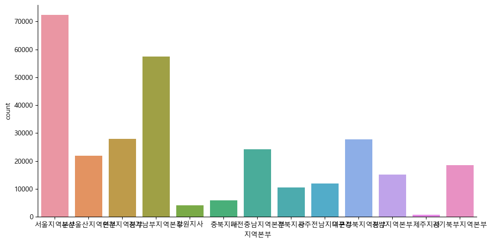

```python
import seaborn as sns

# (폰트가 영어로 설정되어 있어 글자가 깨져서 나왔기에 한글 폰트로 변경하였습니다.)
plt.rcParams['font.family'] = 'Malgun Gothic'
sns.catplot('지역본부', kind = 'count', data = df2, aspect = 2.0)
```

#### ※ (ㄱ)의 결과: '지역본부'의 비율을 확인한 결과, 수도권이 가장 많았고, 그 중에서는 서울과 경기남부가 가장 많았습니다.

#### (ㄴ) '지역본부' 별 '유형' 비율 확인

해당 비율은 서울, 경기남부 순으로 많을 것으로 예상하고, 기존주택의 비율이 가장 높을 것이라 예상합니다.

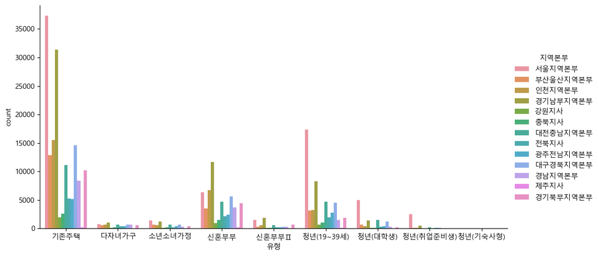

```python
sns.catplot('유형', kind = 'count', hue = '지역본부', data = df2, aspect = 2.0)
```

#### ※ (ㄴ)의 결과: '기존주택'과 '청년', '소년소녀가정'은 서울이 가장 많았고, '신혼부부'는 경기남부에 가장 많았습니다.

## (2) 범주형 * 연속형

'지역본부'별 '방갯수' 비율, '유형'별 '방갯수'가 2개 이하인 비율, '지역본부'별 '전용면적'이 7평(23.14m2) 미만의 주택의 비율, '유형'별 '전용면적'이 7평 미만의 주택 비율을 확인하겠습니다.

### (a) '서울지역본부', '경기남부지역본부'별 '방갯수' 비율

해당 비율은 방이 2개인 주택이 제일 많을 것으로 예상합니다.

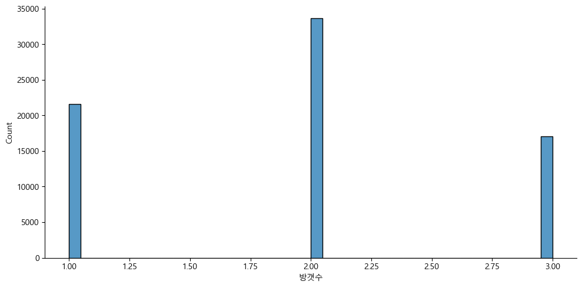

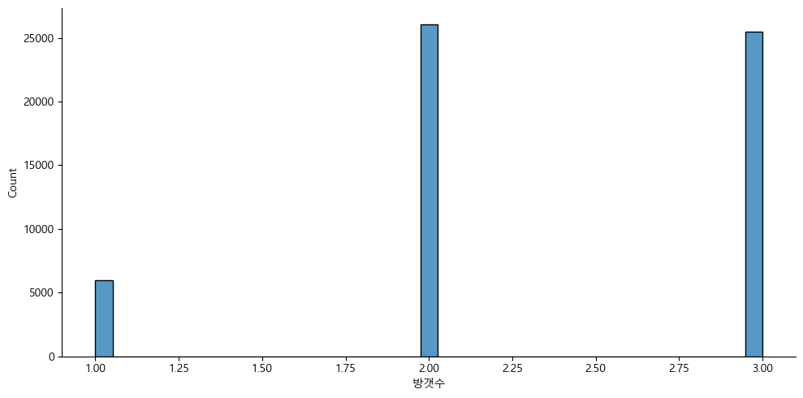

```python
sns.displot(df2['방갯수'].loc[df2['지역본부'] == '서울지역본부'], aspect = 2.0)
sns.displot(df2['방갯수'].loc[df2['지역본부'] == '경기남부지역본부'], aspect = 2.0)
```

### ※ (a)의 결과: 두 지역본부 모두 방갯수가 2개인 비율이 가장 많았고, 서울은 2>1>3, 경기남부는 2>3>1 순으로 많았습니다.

### (b) '유형'별 '방갯수'가 2개 이하인 비율

해당 비율은 가장 많은 유형을 차지하고 있는 기존주택일 것이라고 예상합니다.

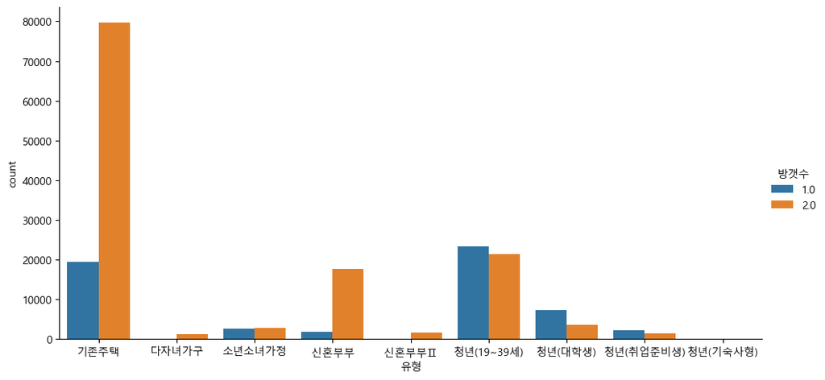

```python
sns.catplot('유형', kind='count', hue='방갯수', data = df2.loc[df2['방갯수'] <= 2.0], aspect = 2.0)
```

### ※ (b)의 결과: '방갯수'가 2개 이하인 주택 중, '저'의 자격에 해당하는 유형은 청년(19~39세)의 비율이 가장 높았고, 그 중 방이 1개인 주택이 조금 더 많았습니다. 청년(대학생) 또한 방이 1개인 주택이 더 많았습니다.

한가지 아쉬운 점이 있다면, 신혼부부 유형은 방이 2개인 주택 비율이 훨씬 높긴 하지만, 1개인 주택도 있는걸로 확인되어 비좁은 주택에 2명 이상이 거주할 수 있도록 주택을 보급한 것이라고 생각합니다.

### (c) '지역본부'별 '전용면적'이 7평(23.14m2) 미만인 주택의 비율

해당 비율은 땅은 좁지만 많은 주택이 즐비하고 있는 서울이 가장 많을 것으로 예상합니다.

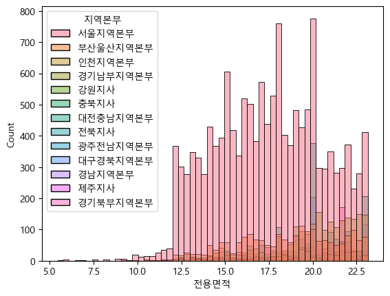

```python
sns.histplot(data = df2[df2['전용면적'] < 23.14], x="전용면적", hue="지역본부")
```

### ※ (c)의 결과: 7평 미만인 주택의 비율은 서울이 가장 높았습니다.

해당 결과의 가장 놀라웠던 부분은 12.5m2 이하의 주택이 있다는 것이었습니다.  
약 3.7평으로 일반 가정집의 작은 방 한 칸정도 되는 크기인데, 저런 크기의 주택이 있다는 것과 전세 매물로 내놓은 것이 매우 안타까운 현실이라고 느꼈습니다.

### (d) '유형'별 '전용면적'이 7평 미만의 주택 비율

해당 비율은 청년(19~39세) 유형이 가장 많을 것으로 예상합니다.

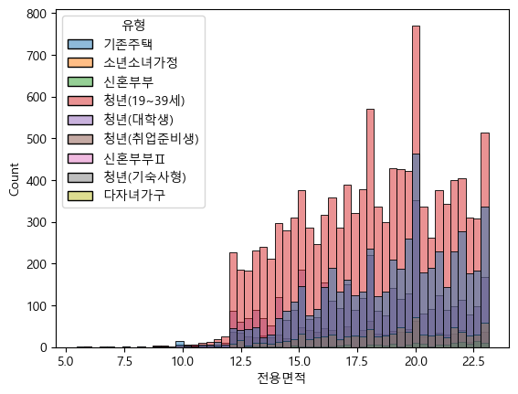

```python
sns.histplot(data = df2[df2['전용면적'] < 23.14], x="전용면적", hue="유형")
```

### ※ (d)의 결과: 지역은 서울이 가장 많았고, 청년(19~39세) 유형이 압도적으로 많았습니다. 또한, 모든 유형 중에서도 청년에 해당하는 유형들의 비율이 가장 높았습니다.

# 6. 데이터 시각화

## 1) 고급 시각화

### (1) 이변수 시각화

#### (a) 연속형 * 연속형

'방갯수'와 '전세금'을 jointplot을 이용하여 '방갯수'에 따른 '전세금'을 확인하도록 하겠습니다. 예상하기를, '방갯수'가 많아질수록 '전세금'이 높아질 것으로 예상합니다.

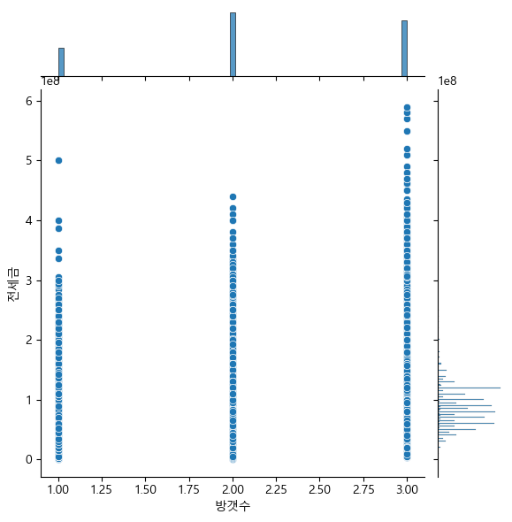

```python
sns.jointplot(x = df2['방갯수'], y = df2['전세금'])
```

### ※ (a)의 결과: 예상한 결과와 일치하는 부분도, 아닌 부분도 있는 걸로 보아 지역적으로 차이가 있을 것으로 생각됩니다.

#### (b) 연속형 * 범주형

(a)에서 나온 결과 중, 지역별로 전세금의 차이가 있는지 확인하기 위해 '전세금'과 '지역본부'를 violinplot을 이용하여 시각화하겠습니다.  
예상하기를, 서울이 가장 전세금이 높을 것이라 생각합니다.

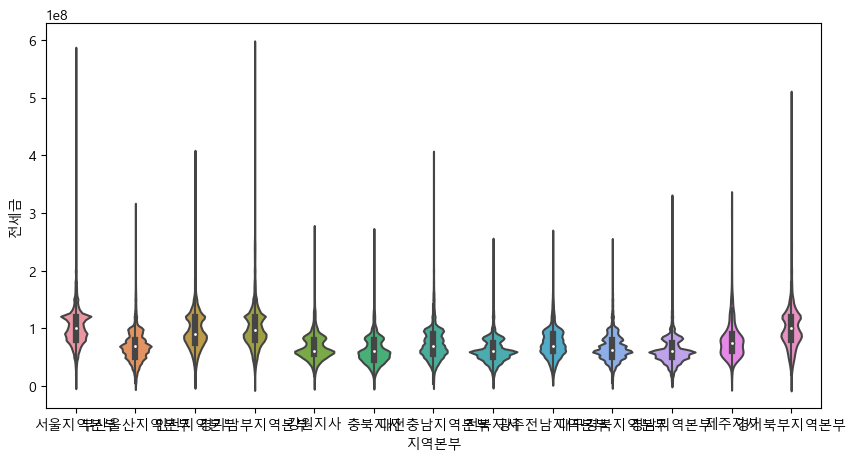

```python
plt.figure(figsize=(10, 5))
sns.violinplot(x = df2['지역본부'], y = df2['전세금'])
```

### ※ (b)의 결과: 예상과 달리 '경기남부지역본부'의 전세금이 가장 높은 것으로 확인되었습니다.

### (2) 다변량 시각화

'지역본부'와 '유형', 그리고 '전세금'으로 stripplot을 이용한 다변량 시각화를 하겠습니다.  
이 시각화를 통해 어느 지역의 어떤 전세주택 '유형'이 '전세금'이 가장 높은지 한 눈에 볼 수 있습니다.  
예상하기를, 서울과 경기남부의 기존주택의 전세금이 가장 높을 것으로 예상됩니다.

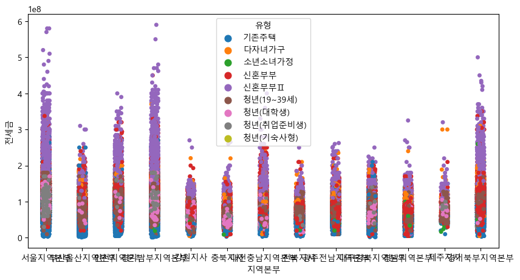

```python
plt.figure(figsize=(10, 5))
sns.stripplot(x = df2['지역본부'], y = df2['전세금'], hue = df2['유형'], jitter = True)
```

### ※ (c)의 결과: 예상과 달리, '신혼부부2' 유형의 주택이 가장 전세금이 높았고, 위와 같이 서울과 경기남부의 전세금이 가장 높았습니다.

# 7. 데이터 또는 분석 과정 차별화 포인트

데이터를 찾을 때, 공공 데이터말고 다른 데이터를 찾고 싶었지만, 그럴 여건이 되지 않아 흔하지 않은 데이터를 찾았지만 관심이 없던 주제였기에 데이터 분석을 하는 흥미가 떨어져 가장 관심이 갔던 부동산 데이터를 찾아보았습니다.  
하지만, 이미 인터넷 상에 부동산 데이터는 너무 많았기에 데이터 분석이 쉽진 않을 것이라 생각했습니다.  
그래서, 데이터 탐색과 데이터 분석을 할 때, '저'의 자격에 맞는 전세주택을 분석하여 찾아내면 분석적으로 차별화될 것이라 생각하였습니다.  
실제로, 요즘 뉴스만 봐도 주거 문제에 대해 고민하고 있는 사람들이 많고, 전세사기도 즐비하기에 토지주택공사의 전세주택에 대한 데이터를 분석하면 많은 사람들의 주거 문제를 해결해 줄 것이라 생각하여 청년의 한 일원인 저를 기준으로 분석을 하였습니다.

# *★한국토지주택공사_임대주택공급현황_전세임대 분석 요약★*

#### 4. 2021~2022년의 수원시 다세대주택 전세금 평균과 2023년의 수원시 다세대주택 전세금 평균을 그룹화하여 비교했습니다.

##### (1) 비교 결과, 2023년의 전세금 평균이 더 높았습니다.

#### 5. '저'의 자격에 맞는 주택의 비율을 seaborn 시각화를 통해 확인하였습니다.

##### (1) '지역본부' 中 '서울지역본부'의 전세주택이 가장 많았습니다.

##### (2) '서울지역본부'의 전세주택 중에는 '기존주택', '청년(19~39세)' 순으로 많았습니다.

##### (3) 전세주택 중에는 방이 2개인 주택이 가장 많았고, 서울은 3개인 주택이, 경기남부는 1개인 주택이 제일 적었습니다.

##### (4) 한 사람이 쾌적하게 살 수 있는 최소한의 방 크기가 7평인데, 그 7평조차 되지 않는 주택의 비율은 서울이 압도적으로 많았고, 그 중'청년'에 해당하는 유형이 가장 많이 차지하였습니다.

#### 6.'경기남부지역본부'와 '서울지역본부'의 '전세금'이 가장 높았고, '전세금'에 따른 '방갯수'의 분포는 일정하진 않았습니다. 이는, 지역적인 차이때문인 것같습니다.

#### 7. '전세금'이 가장 높은 '유형'은 '신혼부부2' 유형인 것으로 나왔고, 역시 '서울지역본부'와 '경기남부지역본부'의 '신혼부부2' 전세금이 가장 높다고 나왔습니다.

# 8. 데이터 분석 수업을 마감하며

사실, 데이터를 분석하는 것에 전혀 흥미도 없고 관심도 없었기에 시험볼 때만 달달 암기하며 공부하자 라는 마음으로 수업을 들었습니다.  
직전 학기에 '데이터베이스'라는 수업을 들을 때에도 "데이터는 석사하는 사람들만 만질 수 있을텐데 내가 왜 배워야하나..."라는 생각으로 강의를 들었지만, ORACLE을 사용하여 기본적인 데이터를 다루는 것이 꽤 흥미로웠고, 그 결과로 SQLD 자격증도 취득하며, 얻어간 것이 많은 수업이라고 생각하였습니다.  
그래서 '빅데이터분석개론' 수업을 들을 때, 데이터 분석 과정 부분에 대해 가장 관심이 갔고, 특히 데이터를 그룹화하여 원하는 데이터를 찾아내는 과정이 제일 흥미로웠습니다.  
또한, seaborn을 이용하여 데이터를 시각화하여 한 눈에 보는 것은 데이터 분석이 개인적으로 필요할 때에도 써먹을 것 같습니다.  
비록, 이 수업을 다 듣고나서도 데이터에 관련된 공부를 더 할 지는 모르겠지만, 약 14주 동안 잘 배웠습니다. 감사합니다!